# 实验三 线性规划

目录

例题 （1）任务分配问题 （2）人员安排问题 习题 1. 鸡场饲料问题。 2. 零件分工问题。 3. 护士雇用问题。

## 例题

#### （1）任务分配问题

```matlab
f = [13 9 10 11 12 8];
A = [0.4 1.1 1   0   0   0;
       0   0 0 0.5 1.2 1.3];
b = [800; 900];
Aeq = [1 0 0 1 0 0;
       0 1 0 0 1 0;
       0 0 1 0 0 1];
Beq = [400; 600; 500];
lb = zeros(6, 1);
% 由于加工的工件个数必须为整数，所以在此替换使用整数线性规划
[x, fval] = intlinprog(f, 1 : 6, A, b, Aeq, Beq, lb)
```

LP: Optimal objective value is 13800.000000. Optimal solution found. Intlinprog stopped at the root node because the objective value is within a gap tolerance of the optimal value, options.AbsoluteGapTolerance = 0 (the default value). The intcon variables are integer within tolerance, options.IntegerTolerance = 1e-05 (the default value).

x = 6×1

0 600.0000 0 400.0000 0 500.0000

fval = 1.3800e+04

#### （2）人员安排问题

```matlab
c = [40 60];
A = [-5 -3];
b = -45;
% 由于加工的工件个数必须为整数，所以在此替换使用整数线性规划
[x, fval] = intlinprog(c, 1 : 2, A, b, [], [], zeros(2, 1), [9; 15])
```

LP: Optimal objective value is 360.000000. Optimal solution found. Intlinprog stopped at the root node because the objective value is within a gap tolerance of the optimal value, options.AbsoluteGapTolerance = 0 (the default value). The intcon variables are integer within tolerance, options.IntegerTolerance = 1e-05 (the default value).

x = 2×1

9.0000 0

fval = 360.0000

## 习题

#### 1. 鸡场饲料问题。

菜鸡场有1000只鸡，用动物饲料和谷物混合喂养。用动物饲料和谷物饲料混合喂养。每天每只鸡平均食混合饲料0.5kg，其中动物饲料所占比例不能少于20%。动物饲料每千克0.30元，谷物饲料每千克0.18元，饲料公司每周进保证供应谷物6000kg，问饲料怎样混合，才能使成本最低？

```matlab
f = [0.3 0.18];
A = [ ...
    -1 -1; ...
    -0.8 0.2; ...
    0 1; ...
];
b = [-500; 0; 6000/7];
[x, fval] = linprog(f, A, b, [], [], zeros(2, 1))
```

Optimal solution found.

x = 2×1

100 400

fval = 102

#### 2. 零件分工问题。

```matlab
f = [2 3 5 3 3 6];
A = [
    1 2 3 0 0 0;
    0 0 0 1 1 3;
    -1 0 0 -1 0 0;
    0 -1 0 0 -1 0;
    0 0 -1 0 0 -1
];
b = [80; 100; -70; -50; -20];
[x, fval] = intlinprog(f, 1 : 6, A, b, [], [], zeros(6, 1))
```

LP: Optimal objective value is 406.666667. Cut Generation: Applied 1 strong CG cut, and 1 Gomory cut. Lower bound is 408.000000. Relative gap is 0.00%. Optimal solution found. Intlinprog stopped at the root node because the objective value is within a gap tolerance of the optimal value, options.AbsoluteGapTolerance = 0 (the default value). The intcon variables are integer within tolerance, options.IntegerTolerance = 1e-05 (the default value).

x = 6×1

68.0000 0 4.0000 2.0000 50.0000 16.0000

fval = 408

#### 3. 护士雇用问题。

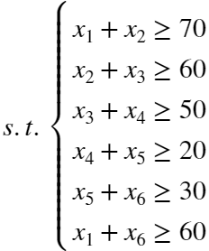

```matlab
f = ones(1, 6);
A = [
    -1 -1 0 0 0 0;
    0 -1 -1 0 0 0;
    0 0 -1 -1 0 0;
    0 0 0 -1 -1 0;
    0 0 0 0 -1 -1;
    -1 0 0 0 0 -1;
];
b = [-70; -60; -50; -20; -30; -60];
[~, fval] = intlinprog(f, 1 : 6, A, b, [], [], zeros(6, 1))
```

LP: Optimal objective value is 150.000000. Optimal solution found. Intlinprog stopped at the root node because the objective value is within a gap tolerance of the optimal value, options.AbsoluteGapTolerance = 0 (the default value). The intcon variables are integer within tolerance, options.IntegerTolerance = 1e-05 (the default value).

fval = 150